# R Notebook

1. From the dataset `heights` in the `dslabs` package, please describe the distribution of male and female heights. If you pick a female at random, what is the probability that she is 61 inches or shorter?

```r
library(dslabs)
library(tidyverse)
library(dplyr)
library(ggplot2)
```

```r
data("heights")

Male<-heights %>% filter(sex=="Male") %>% pull(height)
Female<-heights %>% filter(sex=="Female") %>% pull(height)
```

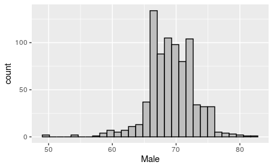

```r
data.frame(Male) %>% ggplot(aes(Male)) + geom_histogram(color = "black", fill="grey")
```

Male의 그래프는 완벽한 normal distribution은 아니지만 비교적 가운데에 몰려서 분ㅠㅗ하고 있음을 알 수 있다.

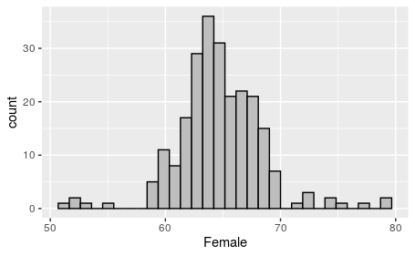

```r
data.frame(Female) %>% ggplot(aes(Female)) + geom_histogram(color = "black", fill="grey")
```

Female의 분포도 완벽하지는 않지만 어느 정도 normal distribution을 따르고 있다.

Female의 값 중 하나를 선택했을 때 그것이 61보다 작거나 같을 확률은 아래와 같다.

```r
mean(Female<=61)
```

```
[1] 0.1218487
```

2. For American Roulette, there are 19 reds, 16 blacks and 3 greens. The payout for winning on green is 15 dollars. You create a random variable that is the sum of your winnings after betting on green 1000 times. Start your code by setting the seed to 1. Describe your random variable (e.g. the expected value, the standard error). Then, create a Monte Carlo simulation that generates 1,000 outcomes of a random variable, and then describe your result.

```r
set.seed(1)
color <- rep(c("Black", "Red", "Green"), c(16, 19, 3))
```

내가 카지노 입장이라고 생각하면, 손님이 green이 나오면 15dollar를 잃고, 아니면 15dollar를 얻는다. 게임을 1000번 했을 때의 결과가 X이고, 1000번의 게임 후 X를 모두 더한 값이 S이다. 1000번의 게임을 한번 실행했을 때 다음과 같은 결과값이 나온다.

```r
n <- 1000
X <- sample(c(-15,15), n, replace = TRUE, prob=c(3/38, 35/38))
S <- sum(X)
S
```

```
[1] 12600
```

S의 standard error와 expected value는 공식에 의해 아래와 같이 계산할 수 있다.

```r
ev<- n * (-15*3/38 + 15*35/38)
se<- sqrt(n) * 2 * sqrt(3*35)/38
```

1000번의 게임을 하는 실행을 1000번 했을 때 나오는 random variable S의 값을 알기 위해 아래와 같이 monte carlo simulation을 한다.

```r
B <- 1000
roulette_winnings <- function(n){
  X <- sample(c(-15,15), n, replace = TRUE, prob=c(3/38, 35/38))
  sum(X)
}
S <- replicate(B, roulette_winnings(n))
```

random variable S의 분포는 아래와 같다.

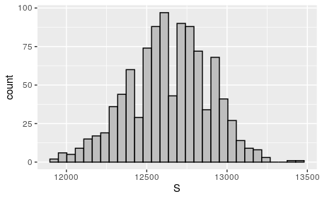

```r
data.frame(S) %>% ggplot(aes(S)) + geom_histogram(color = "black", fill="grey")
```

어느 정도 normal distribution을 따른다.

```r
mean(S<0)
```

```
[1] 0
```

S가 0보다 작을 확률은 0이므로 1000번의 게임을 했을 때, 카지노가 돈을 잃을 일은 없다.

3. From the poll example, we will create a Monte Carlo simulation for p = 0.45. You will compare the sampling size (N) for 10, 1000, and the repeat size (B) for 100, 10000. So you should have four combinations (10 N x 100 B, 1000 N x 100 B, 10 N x 10000 B, 1000 N x 10000 B). Please describe your Monte Carlo simulation results, and compare four combinations.

```r
N <- 1000
B <- 10000
p<-0.45
inside <- replicate(B, {
  x <- sample(c(0,1), size = N, replace = TRUE, prob = c(1-p, p))
  x_hat <- mean(x)
  se_hat <- sqrt(x_hat * (1 - x_hat) / N)
  return(c(x_hat, se_hat))
})

d<-as.data.frame(t(inside))
colnames(d) = c("x_hat", "se_hat")

d<-d %>%
  mutate(low=x_hat - 1.96 * se_hat,
         high = x_hat + 1.96 * se_hat)

plot4<- d %>%
  mutate(poll=seq(1,B), estimate=(low+high)/2) %>%
  head(n=100) %>%
  ggplot(aes(poll,estimate)) +
  geom_point() +  geom_hline(yintercept = p) +
  coord_flip()
```

plot1은 N=10, B=100, plot2는 N=1000, B=100, plot3는 N=10, B=10000, plot4는 N=1000, B=10000일 때이다.

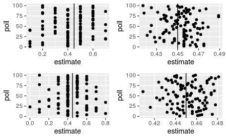

```r
library(cowplot)
plot_grid(plot1, plot2, plot3, plot4)
```